Back to Contents

# Answers to Questions

## 1. Starting Off

### 1

The expression `17` is of type **int** and is a value already. The expression `1 + 2 * 3 + 4` is of type **int** and evaluates to the value `11`, since the multiplication is done first. The expression `800 / 80 / 8` has type **int**. It is the same as `(800 / 80) / 8` rather than `800 / (80 / 8)` and evaluates to `1`.

The expression `400 > 200` has type **bool** because this is the type of the result of the comparison operator `>`. It evaluates to `true`. Similarly, `1 <> 1` has type **bool** and evaluates to `false`. The expression `true || false` is of type **bool** and evaluates to `true` since one of the operands is true. Similarly, `true && false` evaluates to `false` since one of the operands is false. The expression **`if`**`true`**`then`**`false`**`else`**`true` evaluates to `false` since the first (**`then`**) part of the conditional expression is chosen, and takes the place of the entire expression.

The expression `’%’` is of type **char** and is already a value. The expression `’a’ + ’b’` has no type – it gives a type error because the `+` operator does not operate on characters.

### 2

The `mod` operator is of higher precedence than the `+` operator. So `1 + 2 mod 3` and `1 + (2 mod 3)` are the same expression, evaluating to `1 + 2` which is `3`, but `(1 + 2) mod 3` is the same as `3 mod 3`, which is `0`.

### 3

The expression evaluates to `11`. The programmer seems to be under the impression that spacing affects evaluation order. It does not, and so this use of space is misleading.

### 4

The expression `max_int + 1` evaluates to a number equal to `min_int`. Likewise, `min_int - 1` evaluates to a number equal to `max_int`. The number line “wraps around”. This leads to the odd situation that `max_int + 1 < max_int` evaluates to `true`. It follows that when writing programs, we must be careful about what happens when numbers may be very large or very small.

### 5

OCaml accepts the program, but complains when it is run:

`OCaml`  
`# 1 / 0;;`  
`Exception: Division_by_zero.`

We will talk about such *exceptions* later in the book. They are used for program errors which cannot necessarily be found just by looking at the program text, but are only discovered during evaluation.

### 6

For `x mod y`:

- when *y* = 0, OCaml prints `Exception: Division_by_zero`
- when *y* < > 0, *x* < 0, the result will be negative
- when *y* < > 0, *x* = 0, the result will be zero

This illustrates how even simple mathematical operators require careful specification when programming – we must be explicit about the rules.

### 7

It prevents unexpected values: what would happen if an integer other than `1` and `0` was calculated in the program – what would it mean? It is better just to use a different type. We can then show more easily that a program is correct.

### 8

The lowercase characters are in alphabetical order, for example `’p’ < ’q’` evaluates to `true`. The uppercase characters are similarly ordered. The uppercase letters are all “smaller” than the lowercase characters, so for example `’A’ < ’a’` evaluates to `true`. For type **bool**, `false` is considered “less than” `true`.

## 2. Names and Functions

### 1

Just take in an integer and return the number multiplied by ten. The function takes and returns an integer, so the type is **int $→$ int**.

`OCaml`  
`# let times_ten x = x * 10;;`  
`val times_ten : int -> int = <fun>`

### 2

We must take two integer arguments, and use the `&&` and `<>` operators to test if they are both non-zero. So the result will be of type **bool**. The whole type will therefore be **int $→$ int $→$ bool**.

`OCaml`  
`# let both_non_zero x y =`  
`x <> 0 && y <> 0;;`  
`val both_non_zero : int -> int -> bool = <fun>`

### 3

Our function should take an integer, and return another one (the sum). So, it is type will be **int $→$ int**. The base case is when the number is equal to $1$. Then, the sum of all numbers from $1…1$ is just $1$. If not, we add the argument to the sum of all the numbers from 1…(*n*−1).

`OCaml`  
`# let rec sum n =`  
`if n = 1 then 1 else n + sum (n - 1);;`  
`val sum : int -> int = <fun>`

The function is recursive, so we used **`let rec`** instead of **`let`**. What happens if the argument given is zero or negative?

### 4

The function will have type **int $→$ int $→$ int**. A number to the power of $0$ is $1$. A number to the power of $1$ is itself. Otherwise, the answer is the current *n* multiplied by *n*<sup>*x* − 1</sup>.

`OCaml`  
`# let rec power x n =`  
`if n = 0 then 1 else`  
`(if n = 1 then x else`  
`x * power x (n - 1));;`  
`val power : int -> int -> int = <fun>`

Notice that we had to put one **`if`** `…`**`then`** `…`**`else`** inside the **`else`** part of another to cope with the three different cases. The parentheses are not actually required, though, so we may write it like this:

`OCaml`  
`# let rec power x n =`  
`if n = 0 then 1 else`  
`if n = 1 then x else`  
`x * power x (n - 1);;`  
`val power : int -> int -> int = <fun>`

In fact, we can remove the case for `n = 1` since `power x 1` will reduce to `x * power x 0` which is just `x`.

### 5

The function `isconsonant` will have type **char $→$ bool**. If a lower case character in the range `’a’`…`’z’` is not a vowel, it must be a consonant. So we can reuse the `isvowel` function we wrote earlier, and negate its result using the `not` function:

`OCaml`  
`# let isconsonant c = not (isvowel c);;`  
`val isconsonant : char -> bool = <fun>`

### 6

The expression is the same as **`let`**`x = 1`**`in`**`(`**`let`**`x = 2`**`in`**`x + x)`, and so the result is `4`. Both instances of `x` in `x + x` evaluate to `2` since this is the value assigned to the name `x` in the nearest enclosing **`let`** expression.

### 7

We could simply return $0$ for a negative argument. The factorial of $0$ is $1$, so we can change that too, and say our new function finds the factorial of any non-negative number:

`OCaml`  
`# let rec factorial x =`  
`if x < 0 then 0 else`  
`if x = 0 then 1 else`  
`x * factorial (x - 1);;`  
`val factorial : int -> int = <fun>`

Note that `factorial` can fail in other ways too – if the number gets too big and “wraps around”. For example, on the author’s computer, `factorial 40` yields `-2188836759280812032`.

## 3. Case by Case

### 1

We can just pattern match on the boolean. It does not matter, in this instance, which order the two cases are in.

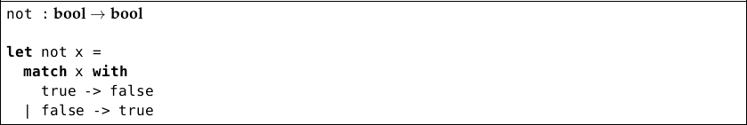

### 2

Recall our solution from the previous chapter:

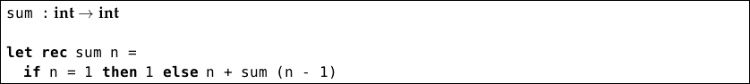

Modifying it to use pattern matching:

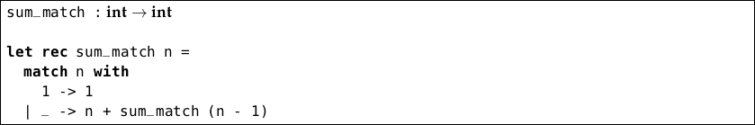

### 3

Again, modifying our solution from the previous chapter:

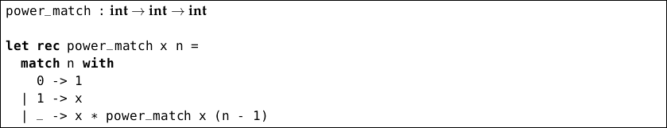

### 5

This is the same as

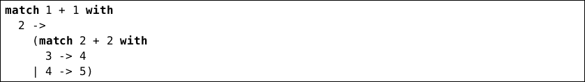

(A match case belongs to its nearest enclosing **`match`**). So the expression evaluates to `5`.

### 6

We write two functions of type **char $→$ bool** like this:

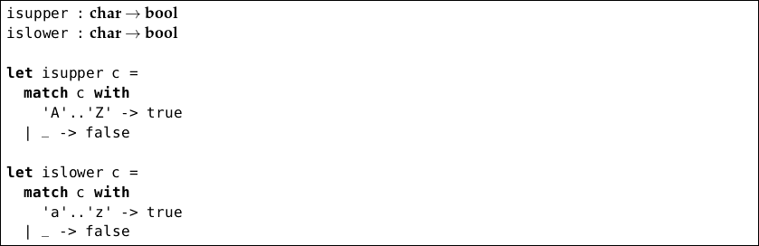

Alternatively, we might write:

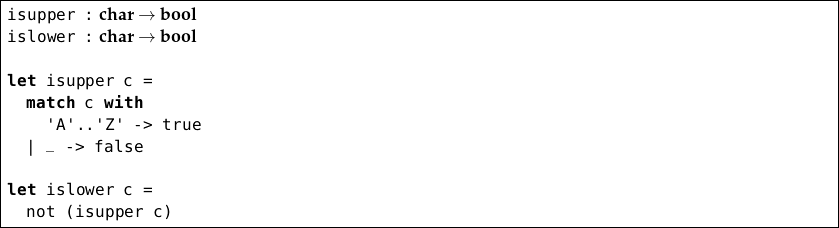

These two solutions have differing behaviour upon erroneous arguments (such as punctuation). Can you see why?

## 4. Listing Things

### 1

This is similar to `odd_elements`:

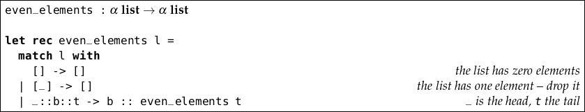

But we can perform the same trick as before, by reversing the cases, to reduce their number:

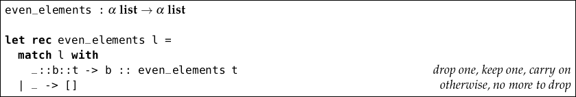

This is like counting the length of a list, but we only count if the current element is `true`.

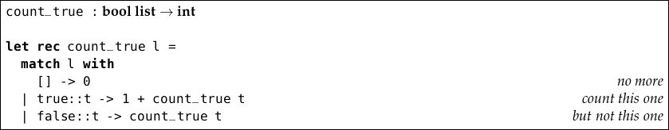

We can use an accumulating argument in an auxiliary function to make a tail recursive version:

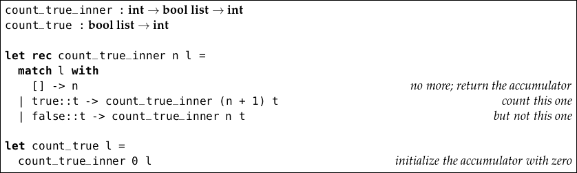

### 3

To make a palindrome from any list, we can append it to its reverse. To check if a list is a palindrome, we can compare it for equality with its reverse (the comparison operators work over almost all types).

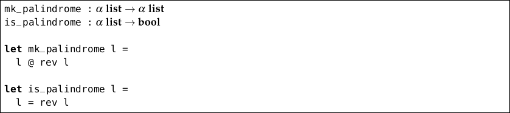

### 4

We pattern match with three cases. The empty list, where we have reached the last element, and where we have yet to reach it.

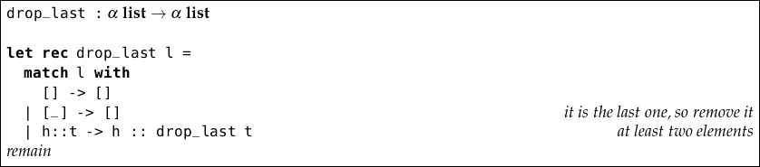

We can build a tail recursive version by adding an accumulating list, and reversing it when finished (assuming a tail recursive `rev`, of course!)

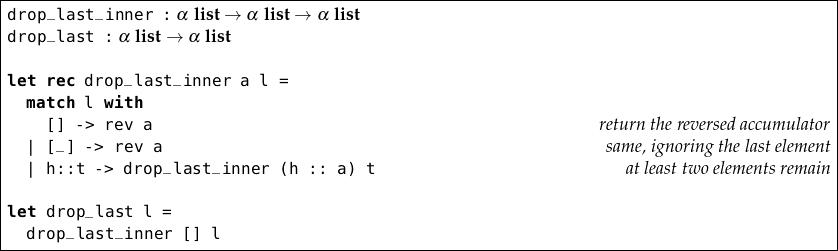

### 5

The empty list cannot contain the element; if there is a non-empty list, either the head is equal to the element we are looking for, or if not, the result of our function is just the same as the result of recursing on the tail.

Note that we are using the property that the `||` operator only evaluates its right hand side if the left hand side is false to limit the recursion – it really does stop as soon as it finds the element.

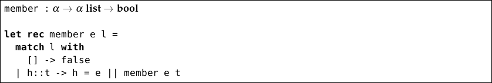

### 6

If a list is empty, it is already a set. If not, either the head exists somewhere in the tail or it does not; if it does exist in the tail, we can discard it, since it will be included later. If not, we must include it.

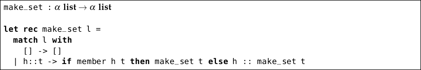

For example, consider the evaluation of `make_set [4; 5; 6; 5; 4]`:

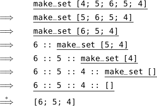

### 7

The first part of the evaluation of `rev` takes time proportional to the length of the list, processing each element once. However, when the lists are appended together, the order of the operations is such that the first argument becomes longer each time. The `@` operator, as we know, also takes time proportional to the length of its first argument. And so, this accumulating of the lists takes time proportional to the square of the length of the list.

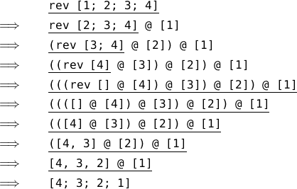

By using an additional accumulating argument, we can write a version which operates in time proportional to the length of the list.

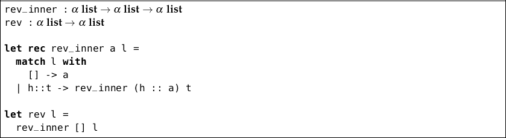

For the same list:

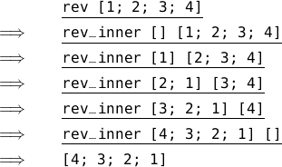

## 5. Sorting Things

### 1

Simply add an extra **`let`** to define a name representing the number we will take or drop:

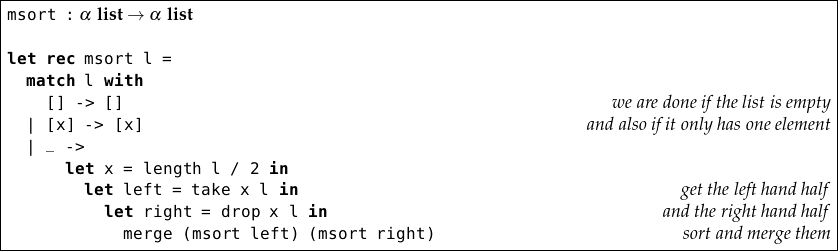

### 2

The argument to `take` or `drop` is `length l / 2` which is clearly less than or equal to `length l` for all possible values of `l`. Thus, `take` and `drop` always succeed. In our case, `take` and `drop` are only called with `length l` more than 1, due to the pattern matching.

### 3

We may simply replace the `<=` operator with the `>=` operator in the `insert` function.

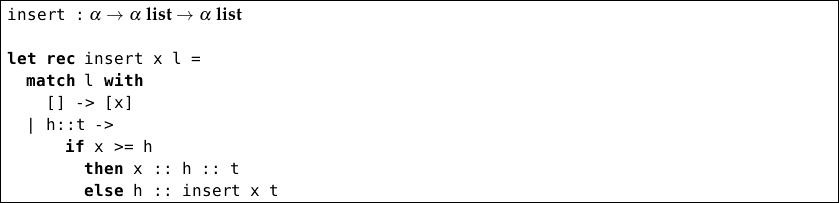

The `sort` function is unaltered.

### 4

We require a function of type *α* list $→$ bool. List of length zero and one are, by definition, sorted. If the list is longer, check that its first two elements are in sorted order. If this is true, also check that the rest of the list is sorted, starting with the second element.

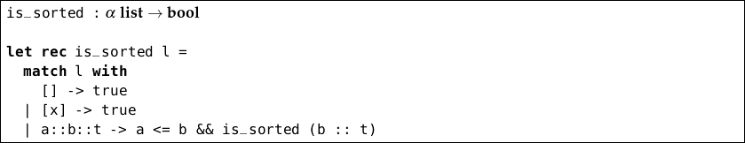

We can reverse the cases to simplify:

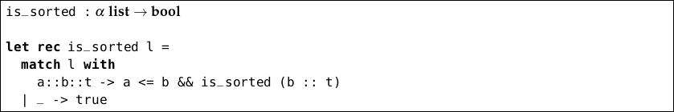

### 5

Lists are compared starting with their first elements. If the elements differ, they are compared, and that is the result of the comparison. If both have the same first element, the second elements are considered, and so on. If the end of one list is reached before the other, the shorter list is considered smaller. For example:

`[1] < [2] < [2; 1] < [2; 2]`

These are the same principles you use to look up a word in a dictionary: compare the first letters – if same, compare the second etc. So, when applied to the example in the question, it has the effect of sorting the words into alphabetical order.

### 6

The **`let rec`** construct can be nested just like the **`let`** construct:

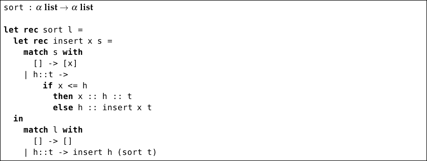

We have renamed the second argument of the `insert` function to avoid confusion.

## Chapter 6. Functions upon Functions upon Functions

### 1

Our function will have type **char list $→$ char list**. We just match on the argument list: if it is empty, we are done. If it starts with an exclamation mark, we output a period, and carry on. If not, we output the character unchanged, and carry on:

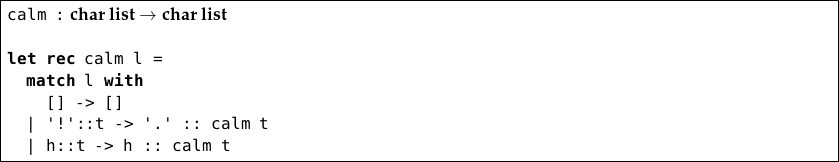

To use `map` instead, we write a simple function `calm_char` to process a single character. We can then use `map` to build our main function:

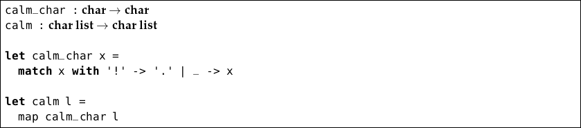

This avoids the explicit recursion of the original, and so it is easier to see what is going on.

### 2

The `clip` function is of type **int $→$ int** and is easy to write:

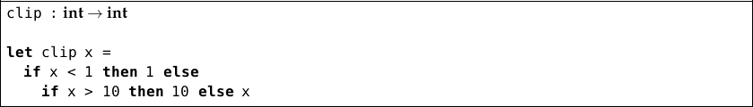

Now we can use map for the `cliplist` function:

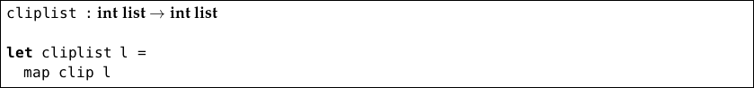

### 3

Just put the body of the clip function inside an anonymous function:

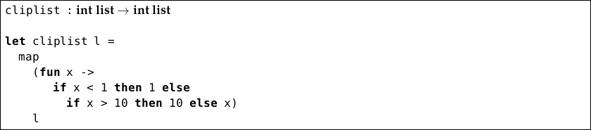

### 4

We require a function `apply f n x` which applies function `f` a total of `n` times to the initial value `x`. The base case is when `n` is zero.

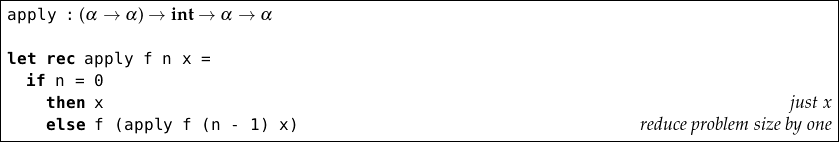

Consider the type:

The function `f` must take and return the same type *α*, since its result in one iteration is fed back in as its argument in the next. Therefore, the argument `x` and the final result must also have type *α*. For example, for *α* = **int**, we might have a power function:

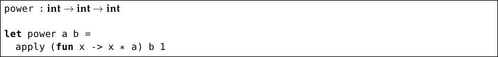

So `power a b` calculates *a*<sup>*b*</sup>.

### 5

We can add an extra argument to the `insert` function, and use that instead of the comparison operator:

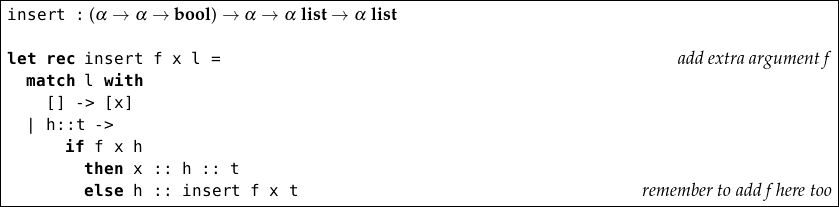

Now we just need to rewrite the `sort` function.

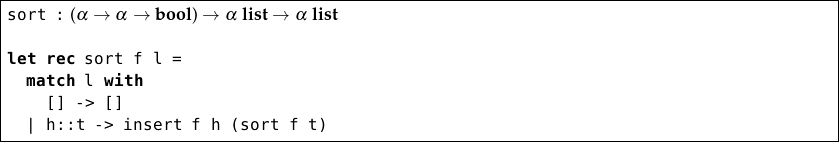

### 6

We cannot use map here, because the result list will not necessarily be the same length as the argument list. The function will have type **(*α* $→$ bool) $→$ *α* list $→$ *α* list**.

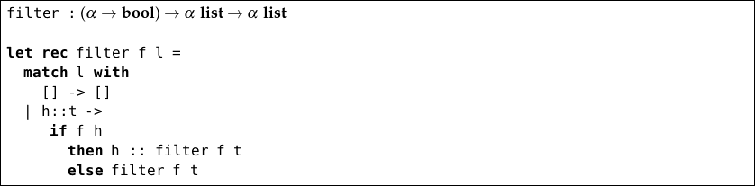

For example, `filter (`**`fun`**`x -> x mod 2 = 0) [1; 2; 4; 5]` evaluates to `[2; 4]`.

### 7

The function will have type **(*α* $→$ bool) $→$ *α* list $→$ bool**.

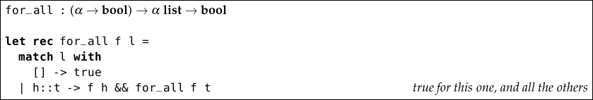

For example, we can see if all elements of a list are positive: `for_all (`**`fun`**`x -> x > 0) [1; 2; -1]` evaluates to `false`. Notice that we are relying on the fact that `&&` only evaluates its right hand side when the left hand side is true to limit the recursion.

### 8

The function will have type **(*α* $→$ *β*) $→$ *α* list list $→$ *β* list list**. We use `map` on each element of the list.

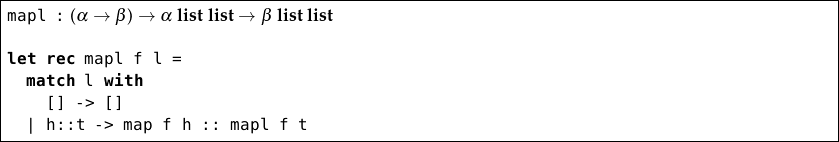

We have used explicit recursion to handle the outer list, and `map` to handle each inner list.

## Chapter 7. When Things go Wrong

### 1

The function `smallest_inner` takes a currently smallest found integer, a boolean value `found` indicating if we have found any suitable value or not, and the list of integers. It is started with `max_int` as the current value, so that any number is smaller than it, and `false` for `found` because nothing has been found yet.

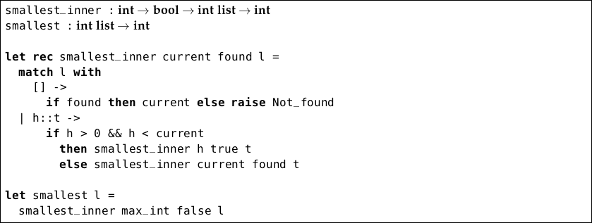

Thus, the function raises an exception in the case of an empty list, or one which is non-empty but contains no positive integer, and otherwise returns the smallest positive integer in the list.

### 2

We just surround the call to `smallest` with an exception handler for `Not_found`.

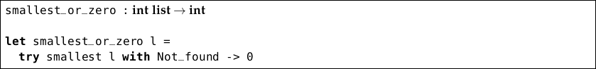

### 3

We write a function `sqrt_inner` which, given a test number `x` and a target number `n` squares `x` and tests if it is more than `n`. If it is, the answer is `x - 1`. The test number will be initialized at `1`. The function `sqrt` raises our exception if the argument is less than zero, and otherwise begins the testing process.

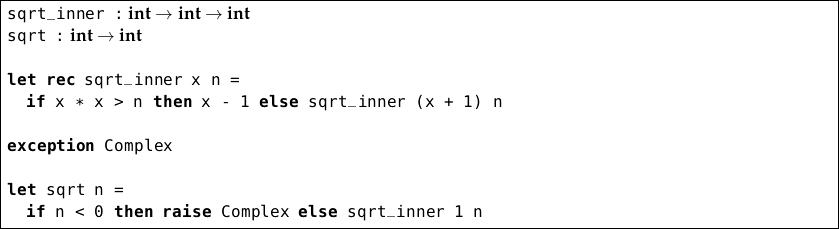

### 4

We wrap up the function, handle the `Complex` exception and return.

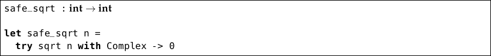

## Chapter 8. Looking Things Up

### 1

Since the keys must be unique, the number of different keys is simply the length of the list representing the dictionary – so we can just use the usual `length` function.

### 2

The type is the same as for the `add` function. However, if we reach the end of the list, we raise an exception, since we did not manage to find the entry to replace.

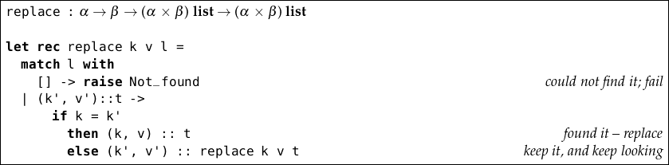

### 3

The function takes a list of keys and a list of values and returns a dictionary. So it will have type *α* list $→$ *β* list $→$ (*α* $×$ *β*) list.

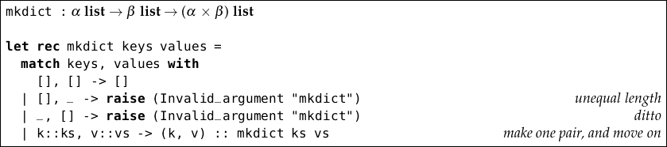

### 4

This will have the type **(*α* $×$ *β*) list $→$ *α* list $×$ *β* list**. For the first time, we need to return a pair, building up both result lists element by element. This is rather awkward, since we will need the tails of both of the eventual results, so we can attach the new heads. We can do this by pattern matching.

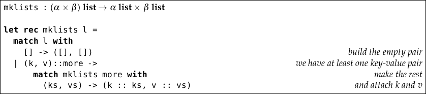

Here’s a sample evaluation (we cannot really show it in the conventional way, so you must work through it whilst looking at the function definition):

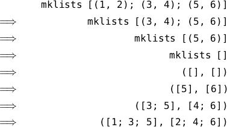

Since the inner pattern match has only one form, and is complete, we can use **`let`** instead:

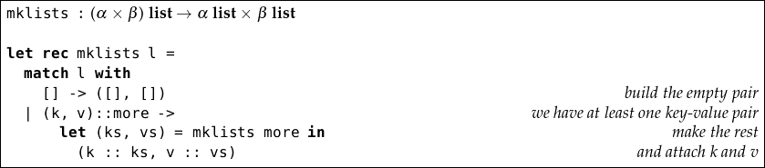

### 5

We can use our `member` function which determines whether an element is a member of a list, building up a list of the keys we have already seen, and adding to the result list of key-value pairs only those with new keys.

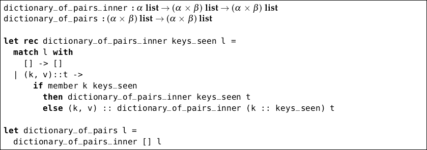

How long does this take to run? Consider how long `member` takes.

### 6

We pattern match on the first list – if it is empty, the result is simply `b`. Otherwise, we add the first element of the first list to the union of the rest of its elements and the second list.

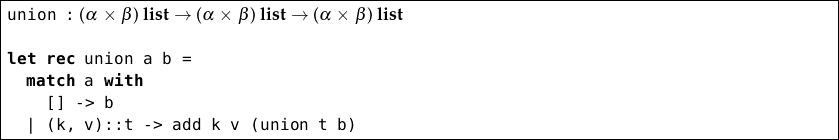

We can verify that the elements of dictionary `a` have precedence over the elements of dictionary `b` by noting that `add` replaces a value if the key already exists.

## Chapter 9. More with Functions

### 1

The function `g a b c` has type *α* $→$ *β* $→$ *γ* $→$ *δ* which can also be written *α* $→$ (*β* $→$ (*γ* $→$ *δ*)). Thus, it takes an argument of type *α* and returns a function of type *β* $→$ (*γ* $→$ *δ*) which, when you give it an argument of type *β* returns a function of type *γ* $→$ *δ* which, when you give it an argument of type *γ* returns something of type *δ*. And so, we can supply just one or two arguments to the function `g` (which is called partial application), or supply all three at once. When we write **`let`**`g a b c = …` this is just shorthand for **`let`**`g =`**`fun`**`a ->`**`fun`**`b ->`**`fun`**`c -> …`

### 2

The type of `member` is *α* $→$ *α* list $→$ bool, so if we supply the first argument, the type of `member x` must be *α* list $→$ bool. We can use the partially-applied `member` function and `map` to produce a list of boolean values, one for each list in the argument, indicating whether or not that list contains the element. Then, we can use `member` again to make sure there are no `false` booleans in the list.

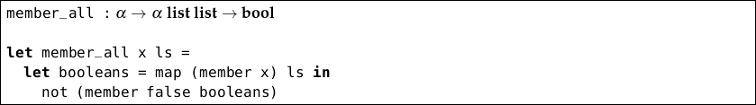

We could also write:

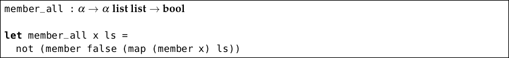

Which do you think is clearer? Why do we check for the absence of `false` rather than the presence of `true`?

### 3

The function `( / ) 2` resulting from the partial application of the `/` operator is the function which divides two by a given number, not the function which divides a given number by two. We can define a reverse divide function…

**`let`**`rdiv x y = y / x`

…which, when partially applied, does what we want.

### 4

The function `map` has type **(*α* $→$ *β*) $→$ *α* list $→$ *β* list**. The function `mapl` we wrote has type **(*α* $→$ *β*) $→$ *α* list list $→$ *β* list list**. So the function `mapll` will have type **(*α* $→$ *β*) $→$ *α* list list list $→$ *β* list list list**. It may be defined thus:

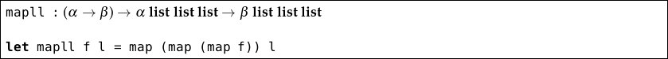

But, as discussed, we may remove the `l`s too:

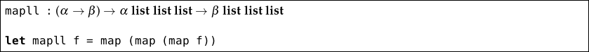

It is not possible to write a function which would map a function `f` over a list, or list of lists, or list of lists of lists depending upon its argument, because every function in OCaml must have a single type. If a function could map `f` over an *α* list list it must inspect its argument enough to know it is a list of lists, thus it could not be used on a *β* list unless *β* = *α* **list**.

### 5

We can write a function to truncate a single list using our `take` function, being careful to deal with the case where there is not enough to take, and then use this and `map` to build `truncate` itself.

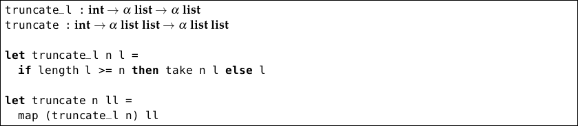

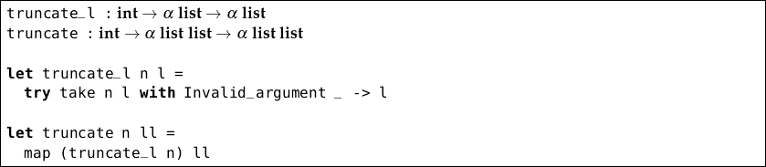

You might, however, reflect on whether or not this is good style.

### 6

First, define a function which takes the given number and a list, returning the first element (or the number if none). We can then build the main function, using partial application to make a suitable function to give to `map`:

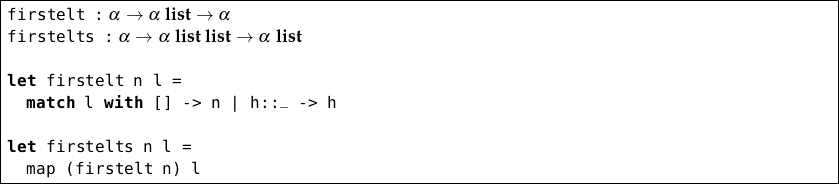

## Chapter 10. New Kinds of Data

### 1

We need two constructors – one for squares, which needs just a single integer (the length of a side), and one for rectangles which needs two integers (the width and height, in that order):

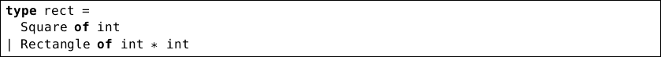

The name of our new type is rect. A rect is either a `Square` or a `Rectangle`. For example,

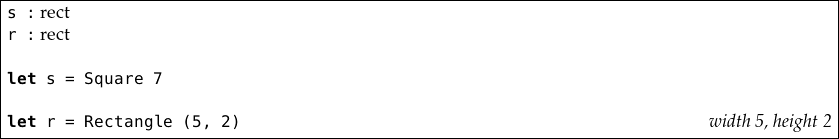

### 2

We pattern match on the argument:

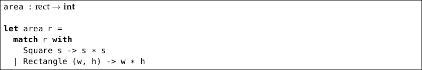

### 3

This will be a function of type rect $→$ rect. Squares remain unaltered, but if we have a rectangle with a bigger width than height, we rotate it by ninety degrees.

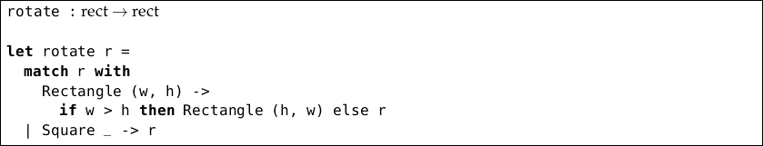

### 4

We will use `map` to perform our rotation on any rects in the argument list which need it. We will then use the sorting function from the previous chapter which takes a custom comparison function so as to just compare the widths.

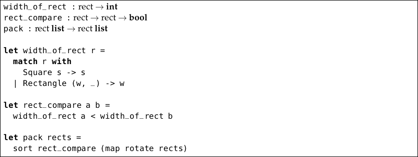

For example, packing the list of rects

`[Square 6; Rectangle (4, 3); Rectangle (5, 6); Square 2]`

will give

`[Square 2; Rectangle (3, 4); Rectangle (5, 6); Square 6]`

### 5

We follow the same pattern as for the **list** type, being careful to deal with exceptional circumstances:

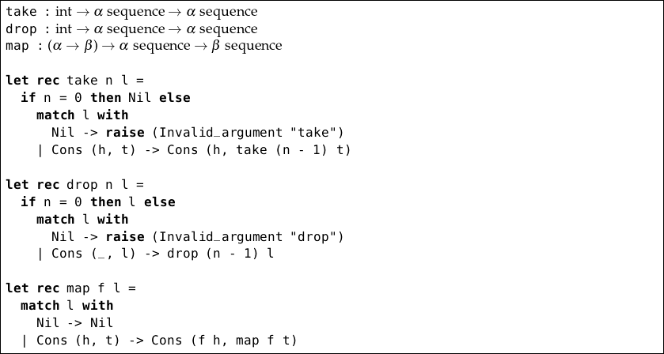

### 6

We can use our `power` function from earlier:

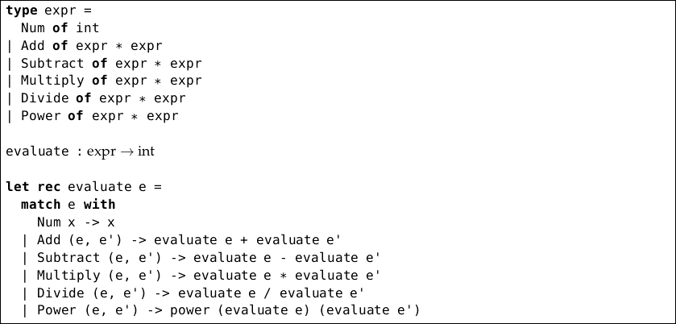

### 7

We can just wrap up the previous function:

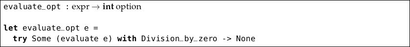